# MFC Microbiome Notebook

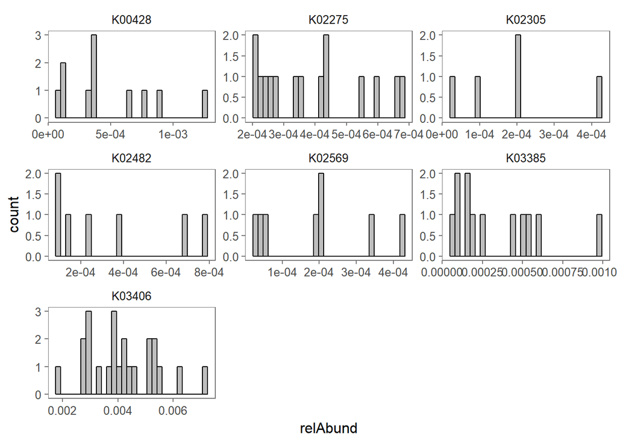

```r
# Box cox, center, scale across KOs for all clusters
# Preprocessing
# Visualize
ggplot(filt_ko_metagenome_contributions,aes(x = relAbund)) +
    facet_wrap(~Gene,scales = "free") +
    geom_histogram(col="black",
                 fill="grey") +
    theme_few()
```

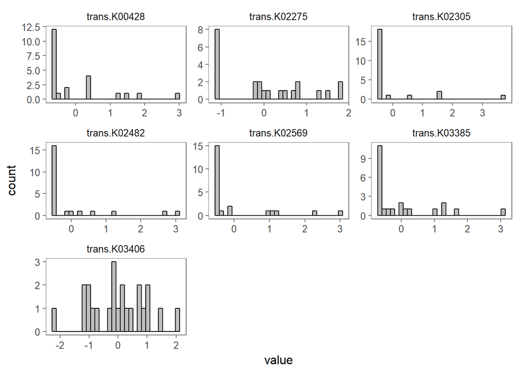

```r
# Transformation
# unstack data
data1 <- melt(filt_ko_metagenome_contributions[,c(1,2,4)], id.vars = c("Gene", "Cluster"))
data1 <- dcast(data1,Cluster~Gene)
# fill NA with zero
data1[is.na(data1)] <- 0
#preprocess
packages(caret)
packages(e1071)
trans = preProcess(data1[,c(2:ncol(data1))], c("BoxCox", "center", "scale"))
cluster_kos_trans = data.frame(trans = predict(trans, data1[,c(2:ncol(data1))]))
# Visualize again
multiplehist <- melt(cluster_kos_trans)
ggplot(multiplehist,aes(x = value)) +
    facet_wrap(~variable,scales = "free") +
    geom_histogram(col="black",
                 fill="grey") +
    theme_few()
```

```r
# Attach cluster number to transformed variables
cluster_kos_trans$Cluster <- data1$Cluster
```

ANOVA on KOs in Clusters

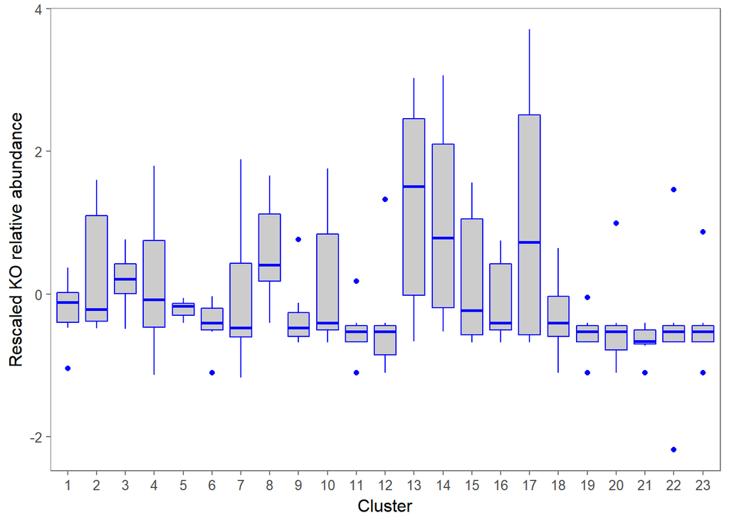

```r
# Format data
cluster_kos_trans_format <- cluster_kos_trans[c(ncol(cluster_kos_trans),1:ncol(cluster_kos_trans)-1)]
data <- melt(cluster_kos_trans_format,id="Cluster")
data[1] <- factor(unlist(data[1]))
ggplot(data, aes(x=Cluster, y = value)) +
    geom_boxplot(fill = "grey80", colour = "blue") +
    scale_x_discrete() + xlab("Cluster") +
    ylab("Rescaled KO relative abundance") +
    theme_few()
```

```r
# Fit a model using the lm function and look at the parameter estimates and standard errors for the treatment effects
  # https://www.r-bloggers.com/one-way-analysis-of-variance-anova/
  model = lm(value ~ Cluster, data = data)
  # We save the model fitted to the data in an object so that we can undertake various actions to study the goodness of the fit to the data and other model assumptions.
  # summary(model)
  # An analysis of variance table for this model can be produced via the anova command
  anova.model = anova(model)
  anova.model
```

```
## Analysis of Variance Table
##
## Response: value
##            Df  Sum Sq Mean Sq F value    Pr(>F)
## Cluster    22  46.986 2.13573  2.7541 0.0001806 ***
## Residuals 138 107.014 0.77546
## ---
## Signif. codes:  0 '***' 0.001 '**' 0.01 '*' 0.05 '.' 0.1 ' ' 1
```

```r
  # The function confint is used to calculate confidence intervals on the treatment parameters, by default 95% confidence intervals
  # confint(model)

# Alternative method (http://personality-project.org/r/r.guide/r.anova.html)
  aov_kos = aov(value~Cluster,data=data)  #do the analysis of variance
  # cat("\n")
  # summary(aov_diversity)                                    #show the summary table
  cat("\n")
```

```r
  print(model.tables(aov_kos,"means"),digits=3)       #report the means and the number of subjects/cell
```

```
## Tables of means
## Grand mean
##
## 6.999827e-16
##
##  Cluster
## Cluster
##      1      2      3      4      5      6      7      8      9     10
## -0.221  0.334  0.192  0.163 -0.213 -0.421 -0.018  0.609 -0.304  0.193
##     11     12     13     14     15     16     17     18     19     20
## -0.527 -0.416  1.250  1.019  0.230 -0.073  1.092 -0.305 -0.559 -0.443
##     21     22     23
## -0.656 -0.498 -0.428
```

```r
# Interpret the Omnibus ANOVA Test Results
  pvaluecolumn <- anova.model$"Pr(>F)" # Extracts p Value column
  pvalue = pvaluecolumn[1] # Extracts first row from p value column
  cat("\n")
```

```r
  cat("ANOVA p Value is",pvalue,"\n") # Displays p Value
```

```
## ANOVA p Value is 0.0001805811
```

```r
  if (pvalue>.05) {
    writeLines("Results are not significant. Fail to reject null hypothesis.")
  } else {
    writeLines("Results are significant. Reject null hypothesis.")
  }
```

```
## Results are significant. Reject null hypothesis.
```

```r
# Run Post-Hoc Tukey HSD between treatment groups
  cat("\n")
```

```r
Tukey <- TukeyHSD(aov_kos)
Tukey$Cluster[Tukey$Cluster[,4]<.05,]
```

```
##            diff         lwr         upr      p adj
## 13-11  1.776670  0.03995029  3.51339034 0.03844371
## 19-13 -1.809404 -3.54612383 -0.07268377 0.03079940
## 21-13 -1.905706 -3.64242563 -0.16898557 0.01554779
## 22-13 -1.747996 -3.48471609 -0.01127603 0.04646597
## 21-17 -1.747741 -3.48446062 -0.01102056 0.04654357
```

Interesting. Why do clusters 13 and 17 have so many exoelectrogenic genes? Let’s make a bar chart of clusters 13 and 17 across our samples.

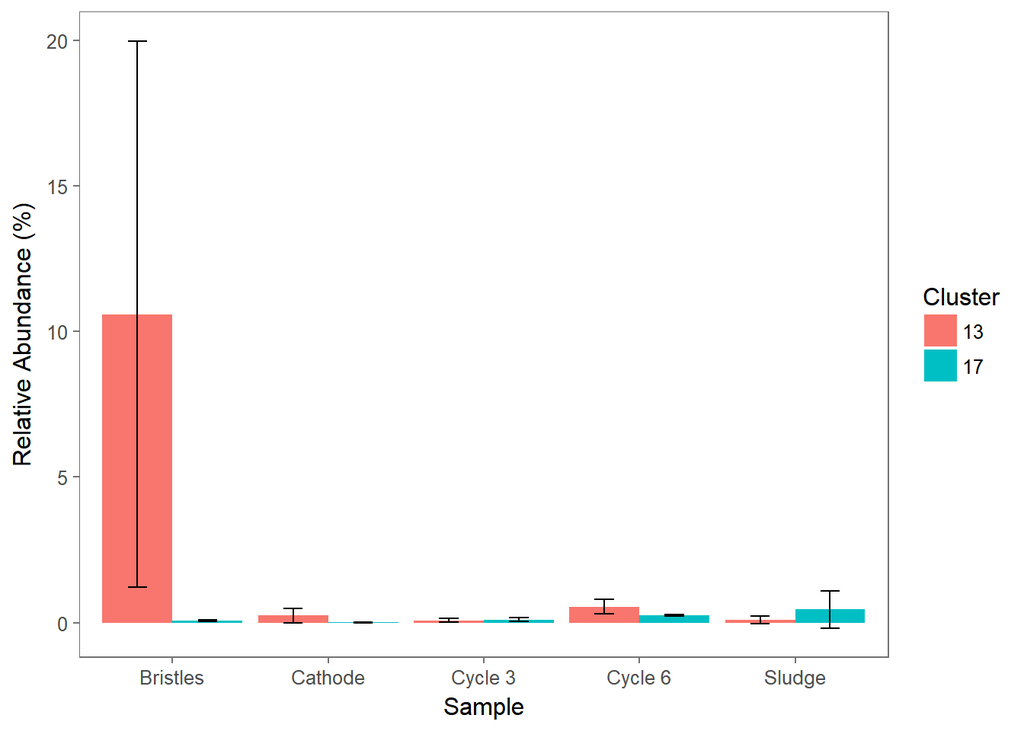

```r
#assign clusters of interest
clusofinterest <- c(13,17)
# make a long form table we can aggregate
ix <- which(colnames(biom$biom_tab) %in% c("Kingdom","Phylum","Class","Order","Family","Genus","Species")) # remove taxonomy info
data <- biom$biom_tab[,-ix]
data <- t(data)
data <- melt(data)
colnames(data) <- c("Label","OTU","Reads")
#assign clusters to OTUs
data$Cluster <- otu_cluster_lookup[match(data$OTU,otu_cluster_lookup$OTU),"Cluster"]
# aggregate reads by label and cluster
agg_data <- aggregate(data$Reads,
    by = list(Label = data$Label, Cluster = data$Cluster),
    FUN = function(x) c(sum = sum(x)))
colnames(agg_data) <- c("Label","Cluster","Cluster_reads_in_label")
# aggregate reads by label
agg_data_label <- aggregate(data$Reads,
    by = list(Label = data$Label),
    FUN = function(x) c(sum = sum(x)))
# attach to agg_data
agg_data$label_reads <- agg_data_label[match(agg_data$Label,agg_data_label$Label),"x"]
# RA
agg_data$RA_cluster_in_label <- 100*agg_data$Cluster_reads_in_label/agg_data$label_reads
#assign samples to labels
agg_data$Sample <- meta[match(agg_data$Label,meta$Label),"Sample"]
#filter for clusters of interest
filter_agg_data <- agg_data[agg_data$Cluster %in% clusofinterest,]

# get data in shape for plotting https://www.r-bloggers.com/building-barplots-with-error-bars/
myData <- aggregate(filter_agg_data$RA_cluster_in_label,
    by = list(Sample = filter_agg_data$Sample, Cluster = filter_agg_data$Cluster),
    FUN = function(x) c(mean = mean(x), sd = sd(x),
                        n = length(x)))

myData <- do.call(data.frame, myData)
myData$se <- myData$x.sd / sqrt(myData$x.n)

colnames(myData) <- c("Sample", "Cluster", "mean", "sd", "n", "se")

myData$names <- c(paste(myData$Sample,"/ Cluster",
                        myData$Cluster))
#Plot
limits <- aes(ymax = myData$mean + myData$sd,
              ymin = myData$mean - myData$sd)

p <- ggplot(data = myData, aes(x = factor(Sample), y = mean,
               fill = factor(Cluster)))

p + geom_bar(stat = "identity",
             position = position_dodge(0.9)) +
  geom_errorbar(limits, position = position_dodge(0.9),
                width = 0.25) +
  labs(x = "Sample", y = "Relative Abundance (%)") +
  scale_fill_discrete(name = "Cluster")+
  theme_few()
```

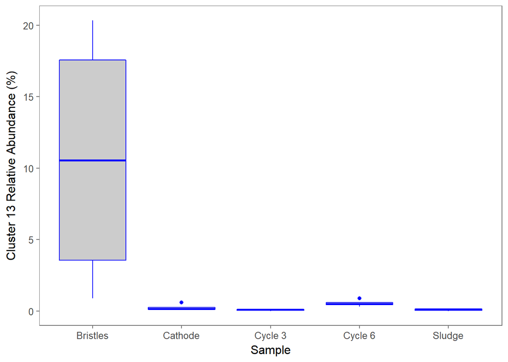

```r
data <- filter_agg_data[filter_agg_data$Cluster %in% 13,]

ggplot(data, aes(x=Sample, y = RA_cluster_in_label)) +
    geom_boxplot(fill = "grey80", colour = "blue") +
    scale_x_discrete() + xlab("Sample") +
    ylab("Cluster 13 Relative Abundance (%)") +
    theme_few()
```

```r
# Fit a model using the lm function and look at the parameter estimates and standard errors for the treatment effects
  # https://www.r-bloggers.com/one-way-analysis-of-variance-anova/
  model = lm(RA_cluster_in_label ~ Sample, data = data)
  # We save the model fitted to the data in an object so that we can undertake various actions to study the goodness of the fit to the data and other model assumptions.
  # summary(model)
  # An analysis of variance table for this model can be produced via the anova command
  anova.model = anova(model)
  anova.model
```

```
## Analysis of Variance Table
##
## Response: RA_cluster_in_label
##           Df Sum Sq Mean Sq F value  Pr(>F)
## Sample     4 332.20  83.050   4.087 0.02323 *
## Residuals 13 264.17  20.321
## ---
## Signif. codes:  0 '***' 0.001 '**' 0.01 '*' 0.05 '.' 0.1 ' ' 1
```

```r
# Alternative method (http://personality-project.org/r/r.guide/r.anova.html)
  aov_kos = aov(RA_cluster_in_label~Sample,data=data)  #do the analysis of variance
  cat("\n")
```

```r
  summary(aov_kos)                                    #show the summary table
```

```
##             Df Sum Sq Mean Sq F value Pr(>F)
## Sample       4  332.2   83.05   4.087 0.0232 *
## Residuals   13  264.2   20.32
## ---
## Signif. codes:  0 '***' 0.001 '**' 0.01 '*' 0.05 '.' 0.1 ' ' 1
```

```r
  cat("\n")
```

```r
  print(model.tables(aov_kos,"means"),digits=3)       #report the means and the number of subjects/cell
```

```
## Tables of means
## Grand mean
##
## 2.554506
##
##  Sample
##     Bristles Cathode Cycle 3 Cycle 6 Sludge
##         10.6   0.243  0.0769   0.544 0.0929
## rep      4.0   4.000  4.0000   4.000 2.0000
```

```r
# Interpret the Omnibus ANOVA Test Results
  pvaluecolumn <- anova.model$"Pr(>F)" # Extracts p RA_cluster_in_label column
  pvalue = pvaluecolumn[1] # Extracts first row from p RA_cluster_in_label column
  cat("\n")
```

```r
  cat("ANOVA p value is",pvalue,"\n") # Displays p value
```

```
## ANOVA p value is 0.02323274
```

```r
  if (pvalue>.05) {
    writeLines("Results are not significant. Fail to reject null hypothesis.")
  } else {
    writeLines("Results are significant. Reject null hypothesis.")
  }
```

```
## Results are significant. Reject null hypothesis.
```

```r
# Run Post-Hoc Tukey HSD between treatment groups
  cat("\n")
```

```r
TukeyHSD(aov_kos)
```

```
##   Tukey multiple comparisons of means
##     95% family-wise confidence level
##
## Fit: aov(formula = RA_cluster_in_label ~ Sample, data = data)
##
## $Sample
##                          diff        lwr        upr     p adj
## Cathode-Bristles -10.34263644 -20.379176 -0.3060969 0.0422036
## Cycle 3-Bristles -10.50845852 -20.544998 -0.4719190 0.0384845
## Cycle 6-Bristles -10.04156704 -20.078107 -0.0050275 0.0498614
## Sludge-Bristles  -10.49246344 -22.784664  1.7997369 0.1104671
## Cycle 3-Cathode   -0.16582208 -10.202362  9.8707175 0.9999981
## Cycle 6-Cathode    0.30106941  -9.735470 10.3376089 0.9999793
## Sludge-Cathode    -0.14982700 -12.442027 12.1423733 0.9999994
## Cycle 6-Cycle 3    0.46689149  -9.569648 10.5034310 0.9998812
## Sludge-Cycle 3     0.01599508 -12.276205 12.3081954 1.0000000
## Sludge-Cycle 6    -0.45089641 -12.743097 11.8413039 0.9999539
```

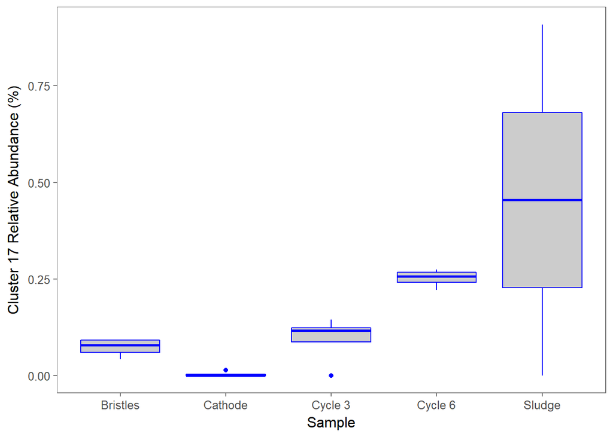

```r
data <- filter_agg_data[filter_agg_data$Cluster %in% 17,]

ggplot(data, aes(x=Sample, y = RA_cluster_in_label)) +
    geom_boxplot(fill = "grey80", colour = "blue") +
    scale_x_discrete() + xlab("Sample") +
    ylab("Cluster 17 Relative Abundance (%)") +
    theme_few()
```

```r
# Fit a model using the lm function and look at the parameter estimates and standard errors for the treatment effects
  # https://www.r-bloggers.com/one-way-analysis-of-variance-anova/
  model = lm(RA_cluster_in_label ~ Sample, data = data)
  # We save the model fitted to the data in an object so that we can undertake various actions to study the goodness of the fit to the data and other model assumptions.
  # summary(model)
  # An analysis of variance table for this model can be produced via the anova command
  anova.model = anova(model)
  anova.model
```

```
## Analysis of Variance Table
##
## Response: RA_cluster_in_label
##           Df  Sum Sq  Mean Sq F value  Pr(>F)
## Sample     4 0.34847 0.087117  2.6431 0.08181 .
## Residuals 13 0.42849 0.032961
## ---
## Signif. codes:  0 '***' 0.001 '**' 0.01 '*' 0.05 '.' 0.1 ' ' 1
```

```r
# Alternative method (http://personality-project.org/r/r.guide/r.anova.html)
  aov_kos = aov(RA_cluster_in_label~Sample,data=data)  #do the analysis of variance
  cat("\n")
```

```r
  summary(aov_kos)                                    #show the summary table
```

```
##             Df Sum Sq Mean Sq F value Pr(>F)
## Sample       4 0.3485 0.08712   2.643 0.0818 .
## Residuals   13 0.4285 0.03296
## ---
## Signif. codes:  0 '***' 0.001 '**' 0.01 '*' 0.05 '.' 0.1 ' ' 1
```

```r
  cat("\n")
```

```r
  print(model.tables(aov_kos,"means"),digits=3)       #report the means and the number of subjects/cell
```

```
## Tables of means
## Grand mean
##
## 0.1444319
##
##  Sample
##     Bristles Cathode Cycle 3 Cycle 6 Sludge
##        0.073 0.00347  0.0941   0.252  0.454
## rep    4.000 4.00000  4.0000   4.000  2.000
```

```r
# Interpret the Omnibus ANOVA Test Results
  pvaluecolumn <- anova.model$"Pr(>F)" # Extracts p RA_cluster_in_label column
  pvalue = pvaluecolumn[1] # Extracts first row from p RA_cluster_in_label column
  cat("\n")
```

```r
  cat("ANOVA p value is",pvalue,"\n") # Displays p value
```

```
## ANOVA p value is 0.0818069
```

```r
  if (pvalue>.05) {
    writeLines("Results are not significant. Fail to reject null hypothesis.")
  } else {
    writeLines("Results are significant. Reject null hypothesis.")
  }
```

```
## Results are not significant. Fail to reject null hypothesis.
```

```r
# Run Post-Hoc Tukey HSD between treatment groups
  cat("\n")
```

```r
TukeyHSD(aov_kos)
```

```
##   Tukey multiple comparisons of means
##     95% family-wise confidence level
##
## Fit: aov(formula = RA_cluster_in_label ~ Sample, data = data)
##
## $Sample
##                         diff         lwr       upr     p adj
## Cathode-Bristles -0.06952317 -0.47373704 0.3346907 0.9811127
## Cycle 3-Bristles  0.02109888 -0.38311500 0.4253128 0.9998124
## Cycle 6-Bristles  0.17926735 -0.22494653 0.5834812 0.6402744
## Sludge-Bristles   0.38121903 -0.11383984 0.8762779 0.1694765
## Cycle 3-Cathode   0.09062204 -0.31359183 0.4948359 0.9514856
## Cycle 6-Cathode   0.24879051 -0.15542336 0.6530044 0.3462661
## Sludge-Cathode    0.45074220 -0.04431668 0.9458011 0.0815976
## Cycle 6-Cycle 3   0.15816847 -0.24604541 0.5623823 0.7339733
## Sludge-Cycle 3    0.36012015 -0.13493872 0.8551790 0.2087746
## Sludge-Cycle 6    0.20195168 -0.29310719 0.6970106 0.7046917
```

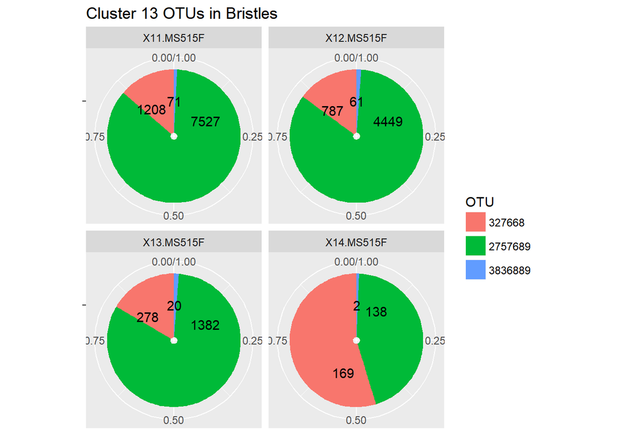

```r
# https://stackoverflow.com/questions/42489277/multiple-ggplot-pie-charts-with-whole-pies
# make a long form table we can aggregate
ix <- which(colnames(biom$biom_tab) %in% c("Kingdom","Phylum","Class","Order","Family","Genus","Species")) # remove taxonomy info
data <- biom$biom_tab[,-ix]
data <- t(data)
data <- melt(data)
colnames(data) <- c("Label","OTU","Reads")
#assign clusters to OTUs
data$Cluster <- otu_cluster_lookup[match(data$OTU,otu_cluster_lookup$OTU),"Cluster"]
# assign samples to labels
data$Sample <- meta[match(data$Label,meta$Label),"Sample"]
# filter for bristles and cluster 13
data <- data[data$Sample=="Bristles" & data$Cluster %in% 13,]
data$OTU <- as.factor(data$OTU)
# plot
ggplot(data = data, aes(x = "", y = Reads, fill = OTU )) +
    geom_bar(stat = "identity", position = position_fill()) +
    geom_text(aes(label = Reads), position = position_fill(vjust = 0.2)) +
    coord_polar(theta = "y") +
    facet_wrap(~ Label)  +
    theme(axis.title.x = element_blank(),
    axis.title.y = element_blank()) + theme(legend.position='right') + guides(fill=guide_legend(nrow=3,byrow=TRUE))+
    ggtitle("Cluster 13 OTUs in Bristles")
```

What taxonomies are associated with these OTUs?

```r
biom$taxon[biom$taxon$otus %in% data$OTU,]
```

```
##         otus     Kingdom             Phylum                   Class
## 16   3836889 k__Bacteria  p__Proteobacteria  c__Deltaproteobacteria
## 967  2757689 k__Bacteria  p__Proteobacteria  c__Deltaproteobacteria
## 1362  327668 k__Bacteria   p__Bacteroidetes          c__Bacteroidia
##                       Order              Family Genus Species
## 16    o__Desulfuromonadales  f__Pelobacteraceae   g__     s__
## 967   o__Desulfuromonadales  f__Pelobacteraceae   g__     s__
## 1362       o__Bacteroidales  f__Marinilabiaceae   g__     s__
```

# Yet to be done: Community Connects to the output

Here we will use ModuleEigengenes from the WGCNA package in R. WGCNA will require several installations from the Bioconductor site. This was developed to link genetic studies to diseases and conditions in the medical field. While WGCNA has their own community detection algorith embedded, this wrapper allows us to substitute our own and establish correlation between our detected communities and variables we’ve recored. The output is ready to be plotted with ggplot2.

```r
  # #first we call the function to establish the relationships.
  # biom_eigen=eigen_correlation(biom$RA.Otus[-c(5,8),],community = biom_info,metadata = meta[-(1:2),],categories = c("Xylanase.IU.g.dry.matter","Endoglucanase.IU..g.dry.matter","cCER"))
  #
  # #from there we can plot these correlations in a heatmap to visualize the relationship.
  # ggplot(data=biom_eigen$melt_cor,aes(x=as.factor(variable), y=category,fill=value))+
  #   geom_tile(colour="#B8B8B8")+
  #   #geom_text(aes(label=value))+
  #   scale_fill_gradient2("Degreee of \n Correlation",guide = "colourbar",high = "#7DEB5F",mid="#F0EE54",low="#F3633F",na.value="white",limits=c(-0.75,0.75))+
  #   ylab("")+
  #   xlab("Cluster/Module")+
  #   labs(fill="Cluster to Deconstruction")+
  #   scale_y_discrete(labels=c("Xylanase","Endoglucanase","cCER"))
  #
  # #we should probably filter on significance though
  # ggplot(data=biom_eigen$melt_cor,aes(x=as.factor(variable), y=category,fill=ifelse(pval<=0.1,value,NA)))+
  #   geom_tile(colour="#B8B8B8")+
  #   #geom_text(aes(label=value))+
  #   scale_fill_gradient2("Degreee of \n Correlation",guide = "colourbar",high = "#7DEB5F",mid="#F0EE54",low="#F3633F",na.value="white",limits=c(-0.75,0.75))+
  #   ylab("")+
  #   xlab("Cluster/Module")+
  #   labs(fill="Cluster to Deconstruction")+
  #   scale_y_discrete(labels=c("Xylanase","Endoglucanase","cCER"))
```